# Building Graphs in R

DataSciencePills

January 2022

————————————————————————————————–

## Packages needed to run this markdown

Whereas no special packages are needed for basic plots in R, throughout this document, there are some snippets of code that use kableExtra and dplyr. KableExtra is extremely useful to build nice-looking tables and dplyr is a package that is often used for data manipulation.

```r
library(kableExtra)
library(dplyr)
```

————————————————————————————————–

## Introduction: basic plots vs GGPlot

The following document covers basic plots in R. There is a very popular package in R called ggplot, which is extremely useful to build nice-looking charts. This document covers basic plots only. Below are some of the key differences between basic plots and ggplot:

| Classic Plots | GGPLOT |
| --- | --- |
| Pre-installed in R | ggplot package installation needed |
| Easy to start with | Needs understanding of basic structure |
| Hard to build complex plots with different information | Easier to use for complex plots |
| One function + other functions that overlay items (e.g text) | Only one function with several layers |

## Dataset Description

The dataset used in this video is the Avocado Prices dataset found in [Kaggle](https://www.kaggle.com/neuromusic/avocado-prices) . It has the following columns:

| Variable | Description |
| --- | --- |
| Date | The date of the observation |
| AveragePrice | The average price of a single avocado |
| Total Volume | The total number of avocados sold |
| 4046 | Total number of avocados with PLU 4046 sold |
| 4225 | Total number of avocados with PLU 4425 sold |
| 4770 | Total number of avocados with PLU 4770 sold |
| Total Bags | *Assumption:* Total number of bags sold* |
| Small Bags | *Assumption:* Total number of small bags sold* |
| Large Bags | *Assumption:* Total number of large bags sold* |
| XLarge Bags | *Assumption:* Total number of Xlarge bags sold* |
| Type | Whether the avocado is conventional or organic (coded as character) |
| Region | Region (coded as character) |

* Not specified in the dataset description, I assume it is the number of bags sold

### Reading and inspecting the dataset

```r
#Reading the dataset, assigning it to a variable called "avocado"
avocado <- read.csv("avocado.csv")

#show the first five rows of avocado
head(avocado) %>%
  kbl() %>%
  kable_styling(font_size = 12) %>%
  scroll_box(width= "600px", height = "300px")
```

| X | Date | AveragePrice | Total.Volume | X4046 | X4225 | X4770 | Total.Bags | Small.Bags | Large.Bags | XLarge.Bags | type | year | region |
| --- | --- | --- | --- | --- | --- | --- | --- | --- | --- | --- | --- | --- | --- |
| 0 | 2015-12-27 | 1.33 | 64236.62 | 1036.74 | 54454.85 | 48.16 | 8696.87 | 8603.62 | 93.25 | 0 | conventional | 2015 | Albany |
| 1 | 2015-12-20 | 1.35 | 54876.98 | 674.28 | 44638.81 | 58.33 | 9505.56 | 9408.07 | 97.49 | 0 | conventional | 2015 | Albany |
| 2 | 2015-12-13 | 0.93 | 118220.22 | 794.70 | 109149.67 | 130.50 | 8145.35 | 8042.21 | 103.14 | 0 | conventional | 2015 | Albany |
| 3 | 2015-12-06 | 1.08 | 78992.15 | 1132.00 | 71976.41 | 72.58 | 5811.16 | 5677.40 | 133.76 | 0 | conventional | 2015 | Albany |
| 4 | 2015-11-29 | 1.28 | 51039.60 | 941.48 | 43838.39 | 75.78 | 6183.95 | 5986.26 | 197.69 | 0 | conventional | 2015 | Albany |
| 5 | 2015-11-22 | 1.26 | 55979.78 | 1184.27 | 48067.99 | 43.61 | 6683.91 | 6556.47 | 127.44 | 0 | conventional | 2015 | Albany |

```r
dim(avocado)
```

```
## [1] 18249    14
```

Lastly, it is always useful to know what is the basic distribution of our variables and what type of variable they are: factor, character, numeric… etc. One of the most useful functions we can use in this case is the function **summary()**

```r
summary(avocado)%>%
  kbl() %>%
  kable_styling(font_size = 12) %>%
  scroll_box(width= "600px", height = "300px")
```

|  | X | Date | AveragePrice | Total.Volume | X4046 | X4225 | X4770 | Total.Bags | Small.Bags | Large.Bags | XLarge.Bags | type | year | region |
| --- | --- | --- | --- | --- | --- | --- | --- | --- | --- | --- | --- | --- | --- | --- |
|  | Min. : 0.00 | Length:18249 | Min. :0.440 | Min. : 85 | Min. : 0 | Min. : 0 | Min. : 0 | Min. : 0 | Min. : 0 | Min. : 0 | Min. : 0.0 | Length:18249 | Min. :2015 | Length:18249 |
|  | 1st Qu.:10.00 | Class :character | 1st Qu.:1.100 | 1st Qu.: 10839 | 1st Qu.: 854 | 1st Qu.: 3009 | 1st Qu.: 0 | 1st Qu.: 5089 | 1st Qu.: 2849 | 1st Qu.: 127 | 1st Qu.: 0.0 | Class :character | 1st Qu.:2015 | Class :character |
|  | Median :24.00 | Mode :character | Median :1.370 | Median : 107377 | Median : 8645 | Median : 29061 | Median : 185 | Median : 39744 | Median : 26363 | Median : 2648 | Median : 0.0 | Mode :character | Median :2016 | Mode :character |
|  | Mean :24.23 | NA | Mean :1.406 | Mean : 850644 | Mean : 293008 | Mean : 295155 | Mean : 22840 | Mean : 239639 | Mean : 182195 | Mean : 54338 | Mean : 3106.4 | NA | Mean :2016 | NA |
|  | 3rd Qu.:38.00 | NA | 3rd Qu.:1.660 | 3rd Qu.: 432962 | 3rd Qu.: 111020 | 3rd Qu.: 150207 | 3rd Qu.: 6243 | 3rd Qu.: 110783 | 3rd Qu.: 83338 | 3rd Qu.: 22029 | 3rd Qu.: 132.5 | NA | 3rd Qu.:2017 | NA |
|  | Max. :52.00 | NA | Max. :3.250 | Max. :62505647 | Max. :22743616 | Max. :20470573 | Max. :2546439 | Max. :19373134 | Max. :13384587 | Max. :5719097 | Max. :551693.7 | NA | Max. :2018 | NA |

```r
#Note: while summary(avocado) would provide us the information, the kbl() function allows us to print a pretty table of that summary.
```

### Brief dataset cleaning

```r
#Removing the index column

avocado <- avocado[,-1 ]

#Turning region and type into factors (categorical variable)
avocado$region <- as.factor(avocado$region)
avocado$type<- as.factor(avocado$type)

#Changing the date into Date
avocado$Date <- as.Date(avocado$Date)

#Checking the changes by calling summary again
summary(avocado)%>%
  kbl() %>%
  kable_styling(font_size = 12) %>%
  scroll_box(width= "600px", height = "300px")
```

|  | Date | AveragePrice | Total.Volume | X4046 | X4225 | X4770 | Total.Bags | Small.Bags | Large.Bags | XLarge.Bags | type | year | region |
| --- | --- | --- | --- | --- | --- | --- | --- | --- | --- | --- | --- | --- | --- |
|  | Min. :2015-01-04 | Min. :0.440 | Min. : 85 | Min. : 0 | Min. : 0 | Min. : 0 | Min. : 0 | Min. : 0 | Min. : 0 | Min. : 0.0 | conventional:9126 | Min. :2015 | Albany : 338 |
|  | 1st Qu.:2015-10-25 | 1st Qu.:1.100 | 1st Qu.: 10839 | 1st Qu.: 854 | 1st Qu.: 3009 | 1st Qu.: 0 | 1st Qu.: 5089 | 1st Qu.: 2849 | 1st Qu.: 127 | 1st Qu.: 0.0 | organic :9123 | 1st Qu.:2015 | Atlanta : 338 |
|  | Median :2016-08-14 | Median :1.370 | Median : 107377 | Median : 8645 | Median : 29061 | Median : 185 | Median : 39744 | Median : 26363 | Median : 2648 | Median : 0.0 | NA | Median :2016 | BaltimoreWashington: 338 |
|  | Mean :2016-08-13 | Mean :1.406 | Mean : 850644 | Mean : 293008 | Mean : 295155 | Mean : 22840 | Mean : 239639 | Mean : 182195 | Mean : 54338 | Mean : 3106.4 | NA | Mean :2016 | Boise : 338 |
|  | 3rd Qu.:2017-06-04 | 3rd Qu.:1.660 | 3rd Qu.: 432962 | 3rd Qu.: 111020 | 3rd Qu.: 150207 | 3rd Qu.: 6243 | 3rd Qu.: 110783 | 3rd Qu.: 83338 | 3rd Qu.: 22029 | 3rd Qu.: 132.5 | NA | 3rd Qu.:2017 | Boston : 338 |
|  | Max. :2018-03-25 | Max. :3.250 | Max. :62505647 | Max. :22743616 | Max. :20470573 | Max. :2546439 | Max. :19373134 | Max. :13384587 | Max. :5719097 | Max. :551693.7 | NA | Max. :2018 | BuffaloRochester : 338 |
|  | NA | NA | NA | NA | NA | NA | NA | NA | NA | NA | NA | NA | (Other) :16221 |

## Basic Plots

### Building a histogram (Univariate, numeric)

A histogram is useful to understand the distribution of numerical variables, that are grouped into “buckets”.

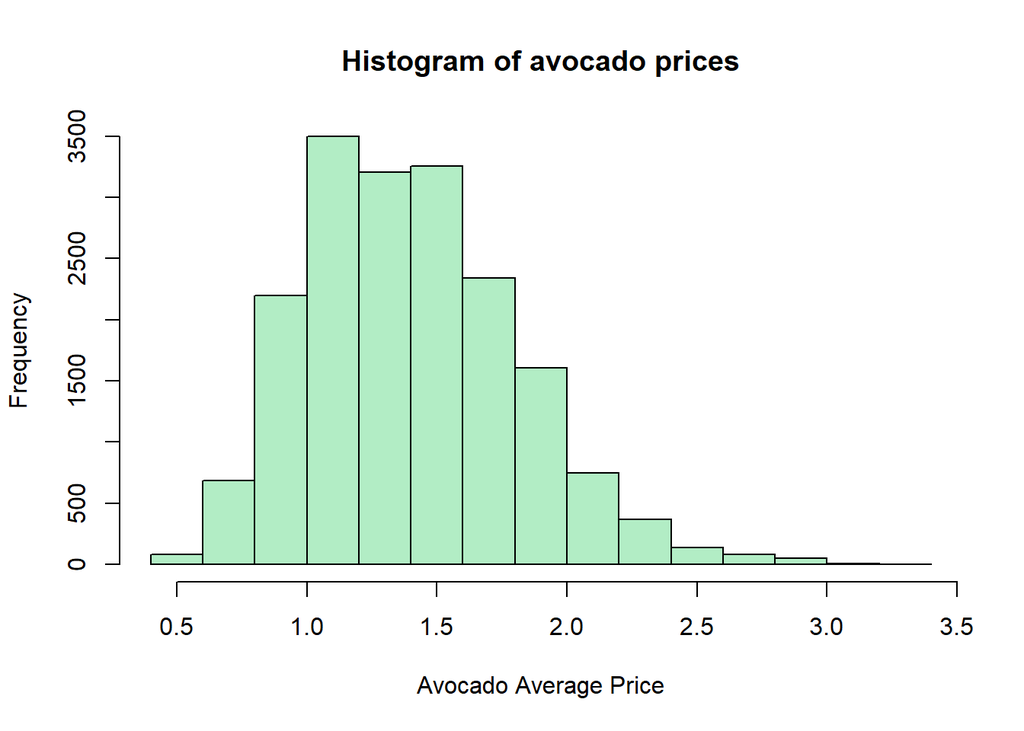

```r
#Building a basic histogram with a title (main), x labelling (xlab) and 15 breaks
colors <- c("#ac3931","#537d8d","#ffbc42","#482c3d","#b2edc5","#0a0908","#e0d3de")

hist(avocado$AveragePrice,
     main = "Histogram of avocado prices",
     xlab = "Avocado Average Price",
     ylab = "Frequency",
     breaks = 15,
     col = colors[5]) #choosing a color
```

### Building a Barchart

Building barchats needs the function barplot(). Barplot works better with named vectors or with two vectors, one with the x values and one with the y values. A simple way of building barcharts is creating a temporary aggregate dataset to group the data you want, then use the height and names.arg arguments to plot that information. For example, if we want to represent the total sales by type, we could:

1. **Aggregate** the data to create a total number of avocados sold by type
2. Use the **height** and **names.arg** parameters of the barplot function to specify the y values and the x values.

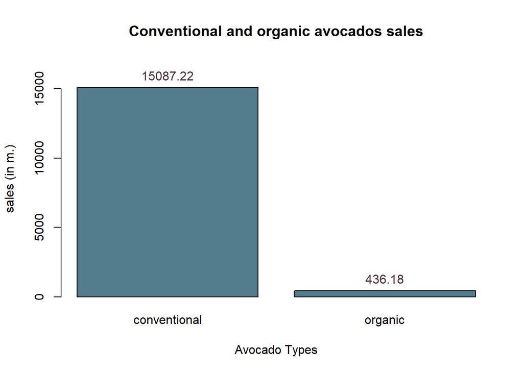

```r
#Aggregating the data
sales_type <- aggregate(x = avocado$Total.Volume,
          by = list(avocado$type),
          FUN = sum)

a <- barplot(height = sales_type$x/1000000,  #If we divide the vector by 1m, we can rescale our y axis
             names.arg=sales_type$Group.1,
             main = "Conventional and organic avocados sales",
             xlab = "Avocado Types",
             ylab = "sales (in m.)",
             ylim = c(0,17000), #setting y limts (needed for the text)
             col=colors[2]) #choosing a color


text(x = a, y= sales_type$x/1000000, label =round(sales_type$x/1000000,2), pos = 3, cex = 1, col = colors[4])
```

To add text to your charts, first build the graph, and then add a text label. The Cex argument is useful to control the font size of your labels.

### Building a pie chart

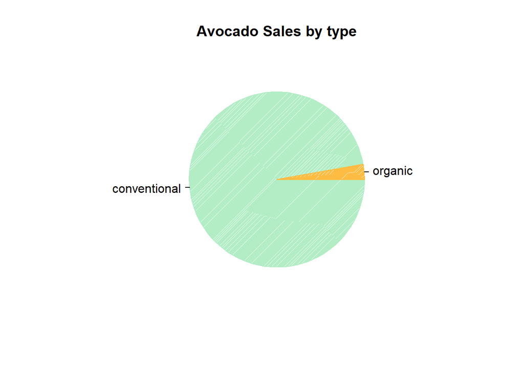

```r
#Similar methodology, but instead of using names.arg, we need to use labels

pie <- pie(sales_type$x,            #numeric information
    labels = sales_type$Group.1,    #labels - so the category names
    main="Avocado Sales by type",           #Plot title
    col = c(colors[5], colors[3]),  #Plot colors
    density = 90,                   #Density of the color (fill)
    init.angle = 10,                #Allow you to rotate the chart
    edges= 100,                     #Number of "edges" of your figure (e.g. you can make a cool polygon)
    )
```

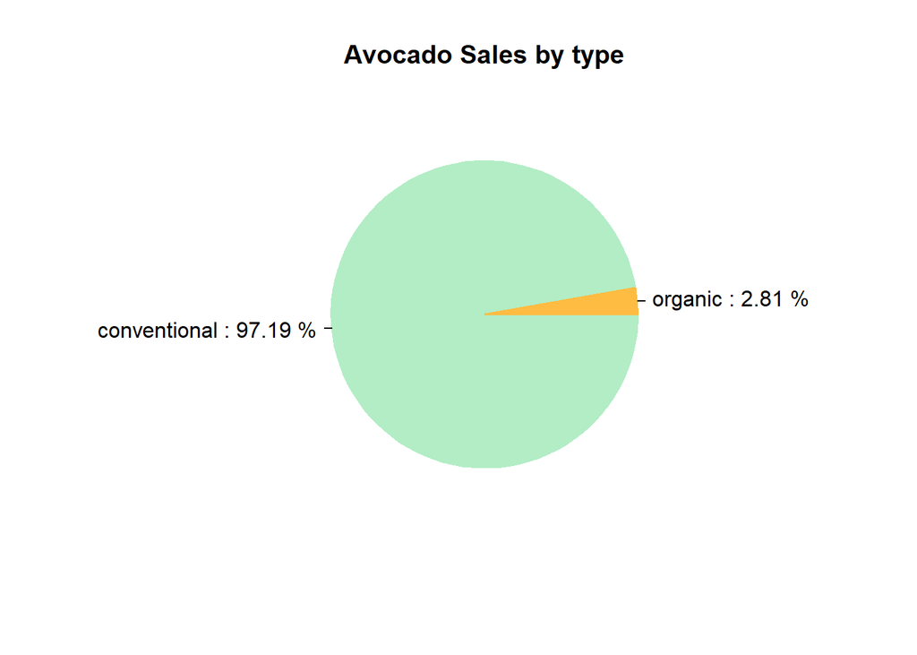

```r
#If you want to add % labels, you need to edit the labels

labels <- paste(sales_type$Group.1, ":", round(sales_type$x/ sum(sales_type$x), 4)*100, "%")

pie <- pie(sales_type$x,                   #numeric information
    labels = labels,    #labels - so the category names
    main="Avocado Sales by type",           #Plot title
    col = c(colors[5], colors[3]),  #Plot colors
    density = 1000,                   #Density of the color (fill)
    init.angle = 10,                #Allow you to rotate the chart
    edges= 100,                     #Number of "edges" of your figure (e.g. you can make a cool polygon)
    )
```

### Building and interpreting a boxplot

Boxplots are a good way to visualise:

- The median of the variable
- The Quartiles of the variable
- The outliers and whether there are any extreme outiers

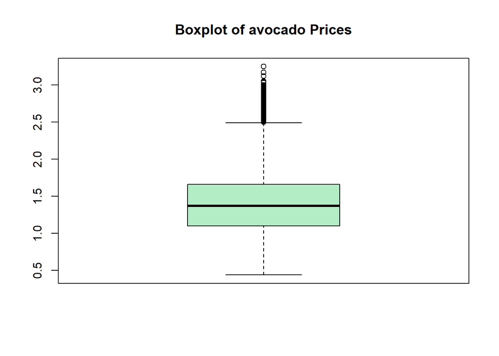

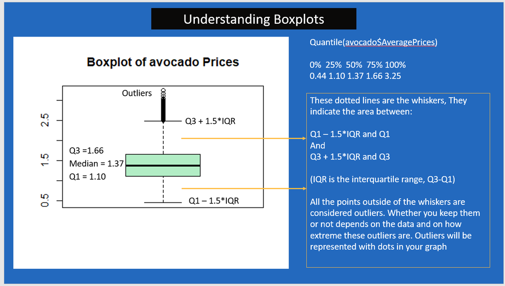

```r
#Avocado price boxplot
boxplot(avocado$AveragePrice, col = colors[5],
        main = "Boxplot of avocado Prices")
```

You can build boxplots per category by using the formula function ~. You basically structure the argument in the following way: y ~ x. Y needs to be a numeric variable and x tends to be a categorical one.

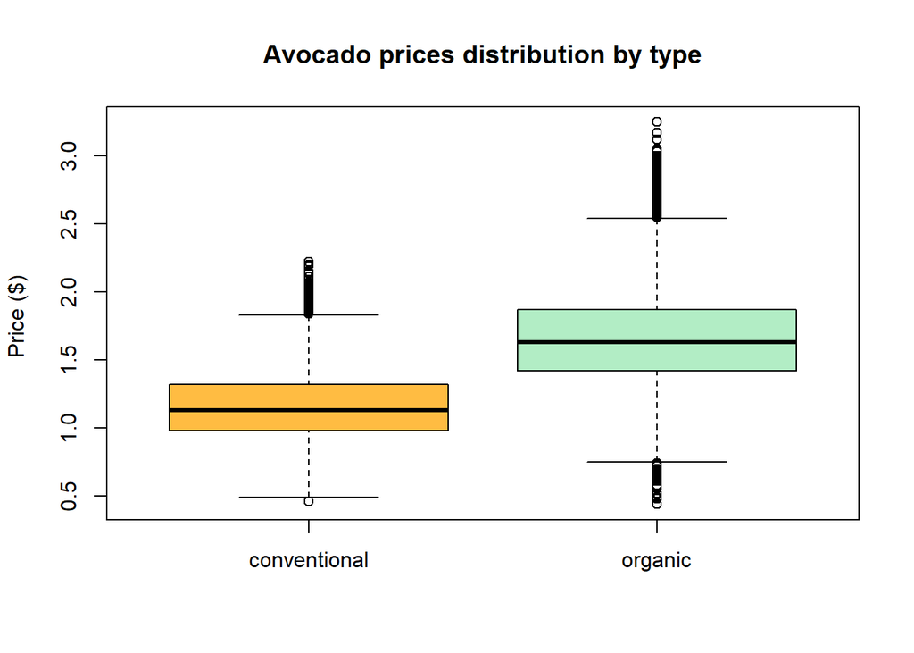

```r
#by type - formula function in plots
boxplot(avocado$AveragePrice ~ avocado$type,
        col=colors[c(3,5)],
        main= "Avocado prices distribution by type",
        ylab="Price ($) ",
        xlab=NULL) #remove Xlab
```

## Challenge

1. Download the avocado dataset and import it into R
2. Build a bar chart of the top 10 avocado selling regions and how much they sell
3. Check the graph: do you see something strange? Would you analyze your data differently after that observation?

### Tips

- Tip: Try using the top_n formula from the dplyr package to isolate the top 10 regions
- Tip 2: par(mar=c(5.1, 6.6, 4.1, 2.1))  use this before your plot to allow for bigger margins for the region names
- Tip3: you can use the argument las=2 to rotate your labels and even horizontal=TRUE to build a horizontal barplot.

### Solution

Check the Challenge solution R file for a possible solution to the problem